# Evaluating Offensive and Defensive Contributions Above Replacement in Baseball with Custom Sabermetrics

## Purpose and Background

In baseball analytics, accurately evaluating player contributions requires metrics that balance offensive and defensive performance while remaining accessible. Established metrics such as WAR (Wins Above Replacement) and DRS (Defensive Runs Saved) are widely used in professional settings but rely on proprietary data and advanced methodologies, making them challenging for amateur teams to implement.

This project introduces two new sabermetrics:

- **Runs Created Above Replacement (RCAR):** A measure of offensive contributions relative to a replacement-level player at the same position.
- **Defensive Value Above Replacement (DVAR):** A measure of defensive contributions relative to a replacement-level player at the same position.

By focusing on these metrics, we aim to bridge the gap between professional-grade analytics and the needs of amateur or collegiate teams, providing actionable and easy-to-calculate insights.

## Research Question

- **How can we develop accessible, position-specific metrics for offensive and defensive player value relative to a replacement player, enabling fair comparisons across players and aiding team decision-making processes?**

## Hypothesis

1. **RCAR Hypothesis:** RCAR will reliably measure a player’s offensive value relative to a replacement-level player at the same position, offering equitable comparisons within specific positions and highlighting impactful players.
2. **DVAR Hypothesis:** DVAR will reliably measure a player’s defensive value relative to a replacement-level player at the same position, offering equitable comparisons within specific positions and highlighting impactful players.
   - **Note:** DVAR may vary significantly by position, reflecting unique defensive demands. However, DVAR may overvalue certain positions, such as catcher and first base, due to structural biases in defensive statistics.

## Objectives

This study aims to:

1. Derive RCAR and DVAR using publicly available MLB data.
2. Compare RCAR and DVAR to established benchmarks (WAR for offense, DRS for defense).
3. Analyze player performance differences by position.
4. Highlight trends and outliers through statistical analysis and visualization.

## Significance

RCAR and DVAR are designed to:

- Evaluate players equitably within their positions.
- Facilitate comparisons across positions.
- Empower amateur and collegiate-level teams to make informed decisions using accessible data.

This analysis validates the proposed metrics against professional benchmarks and explores their strengths and limitations, particularly their potential biases, such as overvaluing specific positions like catchers and first basemen.

```python
import matplotlib.pyplot as plt
import seaborn as sns
import pandas as pd
from scipy.stats import f_oneway, pearsonr
import numpy as np
```

```python
# Read data sets
# Retrieved using pybaseball with /data_download.py on 9 Nov 2024

batting_data = pd.read_csv('batting_data.csv')
fielding_data = pd.read_csv('fielding_data.csv')
```

```python
# Head of each dataset
print("\nBatting Data Sample:")
print(batting_data.head())
print("\nFielding Data Sample:")
print(fielding_data.head())
```

```
Batting Data Sample:
    IDfg  Season               Name Team  Age    G   AB   PA    H   1B  ...  \
0  10155    2014         Mike Trout  LAA   22  157  602  705  173   89  ...
1   9166    2014       Buster Posey  SFG   27  147  547  605  170  118  ...
2   9847    2014   Andrew McCutchen  PIT   27  146  548  648  172  103  ...
3   7870    2014    Jonathan Lucroy  MIL   28  153  585  655  176  108  ...
4   4949    2014  Giancarlo Stanton  MIA   24  145  539  638  155   86  ...

   maxEV  HardHit  HardHit%  Events  CStr%   CSW%  xBA  xSLG  xwOBA  L-WAR
0    NaN      0.0       NaN       0  0.211  0.287  NaN   NaN    NaN    8.3
1    NaN      0.0       NaN       0  0.179  0.239  NaN   NaN    NaN    7.5
2    NaN      0.0       NaN       0  0.152  0.247  NaN   NaN    NaN    7.4
3    NaN      0.0       NaN       0  0.208  0.258  NaN   NaN    NaN    7.4
4    NaN      0.0       NaN       0  0.157  0.286  NaN   NaN    NaN    6.8

[5 rows x 320 columns]

Fielding Data Sample:
    IDfg  Season             Name Team Pos    G   GS     Inn    PO   A  ...  \
0   3648    2014      Rene Rivera  SDP   C   89   85   734.0   680  66  ...
1  13265    2014      Mike Zunino  SEA   C  130  125  1121.0  1009  85  ...
2   7870    2014  Jonathan Lucroy  MIL   C  136  133  1182.1  1013  65  ...
3   3364    2014   Miguel Montero  ARI   C  131  130  1152.0  1037  65  ...
4   4616    2014   Russell Martin  PIT   C  107  106   940.2   785  90  ...

   60-90%  # 60-90%  90-100%  # 90-100%   rSZ  rCERA  rTS   FRM  OAA  Range
0   0.857      0.07    0.957       0.23   9.0    0.0  NaN  20.1  NaN    NaN
1   0.714      0.07    1.000       0.33  16.0   -4.0  NaN  19.0  NaN    NaN
2   0.778      0.09    0.971       0.34  14.0    1.0  NaN  18.2  NaN    NaN
3   0.875      0.08    0.963       0.27  15.0   -1.0  NaN  20.1  NaN    NaN
4   0.500      0.04    0.976       0.41   8.0    3.0  NaN  11.6  NaN    NaN

[5 rows x 63 columns]
```

```python
# Check full size of data sets
print(f"Filtered Batting Data Shape: {batting_data.shape}")
print(f"Filtered Fielding Data Shape: {fielding_data.shape}")
```

```
Filtered Batting Data Shape: (15371, 320)
Filtered Fielding Data Shape: (24075, 63)
```

## Data Overview and Preparation

- **Batting Data:** Includes metrics such as plate appearances (PA), at-bats (AB), hits (H), home runs (HR), and WAR.
- **Fielding Data:** Includes metrics such as putouts (PO), assists (A), errors (E), and defensive runs saved (DRS).

### Filtering Criteria:

1. **Batting Data:** Only players with a minimum of 150 plate appearances (PA) are included to ensure meaningful offensive data.
2. **Fielding Data:** Only players with at least 0.5 innings per game are included to ensure sufficient defensive sample size.
3. **Pitchers Removed:** Pitchers are excluded, as they no longer bat after the Universal Designated Hitter rule.

```python
# Reduce data dimensions to only include relevant columns for RCAR and DVAR calculations

batting_columns = ['IDfg', 'Season', 'Name', 'Team', 'AB', 'H', 'BB', 'SO', 'SB',
                   '1B', '2B', '3B', 'HR', 'OPS', 'SLG', 'PA', 'WAR']
batting_data_reduced = batting_data[batting_columns]


fielding_columns = ['IDfg', 'Season', 'Name', 'Team', 'Pos', 'PO', 'A', 'E', 'Inn',
                    'DP', 'rSZ', 'DRS', 'UZR', 'G']
fielding_data_reduced = fielding_data[fielding_columns]
```

```python
# Filter Batting Data: Minimum Plate Appearances (PA) to ensure meaningful data
min_pa = 150  # MLB-qualified threshold: 3.1 PA per scheduled game
batting_data_reduced = batting_data_reduced[batting_data_reduced['PA'] >= min_pa]

# Filter Fielding Data: Minimum Innings Played
min_innings = 0.5 * 162  # 0.5 innings per game
fielding_data_reduced = fielding_data_reduced[fielding_data_reduced['Inn'] >= min_innings]

# Remove Pitchers from both datasets
fielding_data_reduced = fielding_data_reduced[fielding_data_reduced['Pos'] != 'P']
batting_data_reduced = batting_data_reduced[~batting_data_reduced['IDfg'].isin(
    fielding_data_reduced[fielding_data_reduced['Pos'] == 'P']['IDfg']
)]
```

```python
# Confirm filtering results
print(f"Filtered Batting Data Shape: {batting_data_reduced.shape}")
print(f"Filtered Fielding Data Shape: {fielding_data_reduced.shape}")
```

```
Filtered Batting Data Shape: (4216, 17)
Filtered Fielding Data Shape: (7597, 14)
```

```python
# View reduced data
print("Reduced Batting Data Sample:")
print(batting_data_reduced.head())
```

```
Reduced Batting Data Sample:
    IDfg  Season               Name Team   AB    H  BB   SO  SB   1B  2B  3B  \
0  10155    2014         Mike Trout  LAA  602  173  83  184  16   89  39   9
1   9166    2014       Buster Posey  SFG  547  170  47   69   0  118  28   2
2   9847    2014   Andrew McCutchen  PIT  548  172  84  115  18  103  38   6
3   7870    2014    Jonathan Lucroy  MIL  585  176  66   71   4  108  53   2
4   4949    2014  Giancarlo Stanton  MIA  539  155  94  170  13   86  31   1

   HR    OPS    SLG   PA  WAR
0  36  0.939  0.561  705  8.3
1  22  0.854  0.490  605  7.5
2  25  0.952  0.542  648  7.4
3  13  0.837  0.465  655  7.4
4  37  0.950  0.555  638  6.8
```

```python
print("\nReduced Fielding Data Sample:")
print(fielding_data_reduced.head())
```

```
Reduced Fielding Data Sample:
    IDfg  Season             Name Team Pos    PO   A   E     Inn  DP   rSZ  \
0   3648    2014      Rene Rivera  SDP   C   680  66   8   734.0   2   9.0
1  13265    2014      Mike Zunino  SEA   C  1009  85   5  1121.0   1  16.0
2   7870    2014  Jonathan Lucroy  MIL   C  1013  65   4  1182.1   1  14.0
3   3364    2014   Miguel Montero  ARI   C  1037  65  13  1152.0   4  15.0
4   4616    2014   Russell Martin  PIT   C   785  90   5   940.2   3   8.0

    DRS  UZR    G
0  15.0  NaN   89
1   8.0  NaN  130
2  23.0  NaN  136
3  10.0  NaN  131
4  21.0  NaN  107
```

```python
# Check for missing values in reduced datasets
print("\nMissing Values in Batting Data:")
print(batting_data_reduced.isnull().sum())

print("\nMissing Values in Fielding Data:")
print(fielding_data_reduced.isnull().sum())
```

```
Missing Values in Batting Data:
IDfg      0
Season    0
Name      0
Team      0
AB        0
H         0
BB        0
SO        0
SB        0
1B        0
2B        0
3B        0
HR        0
OPS       0
SLG       0
PA        0
WAR       0
dtype: int64

Missing Values in Fielding Data:
IDfg         0
Season       0
Name         0
Team         0
Pos          0
PO           0
A            0
E            0
Inn          0
DP           0
rSZ       6045
DRS          0
UZR        906
G            0
dtype: int64
```

```python
# Summary statistics for filtered datasets
print("\nSummary Statistics for Batting Data:")
print(batting_data_reduced.describe())
```

```
Summary Statistics for Batting Data:
               IDfg       Season           AB            H           BB  \
count   4216.000000  4216.000000  4216.000000  4216.000000  4216.000000
mean   12105.064753  2019.014231   362.241935    92.600095    34.336575
std     6458.926738     3.226857   148.784117    44.147090    20.680691
min       25.000000  2014.000000   125.000000    17.000000     1.000000
25%     6876.000000  2016.000000   224.000000    53.000000    19.000000
50%    12064.500000  2019.000000   352.000000    87.000000    29.000000
75%    16442.000000  2022.000000   493.000000   128.000000    46.000000
max    33824.000000  2024.000000   684.000000   225.000000   145.000000

                SO           SB           1B           2B           3B  \
count  4216.000000  4216.000000  4216.000000  4216.000000  4216.000000
mean     85.709203     6.046252    59.490512    18.458491     1.744307
std      38.077661     8.198457    29.396902     9.846277     2.009843
min       8.000000     0.000000     7.000000     1.000000     0.000000
25%      56.000000     1.000000    34.000000    10.000000     0.000000
50%      79.000000     3.000000    55.000000    17.000000     1.000000
75%     111.000000     8.000000    81.000000    25.000000     3.000000
max     219.000000    73.000000   170.000000    59.000000    15.000000

                HR          OPS          SLG           PA          WAR
count  4216.000000  4216.000000  4216.000000  4216.000000  4216.000000
mean     12.906784     0.730628     0.411455   404.647770     1.454957
std       9.616938     0.103690     0.074951   166.793659     1.801229
min       0.000000     0.399000     0.187000   150.000000    -2.500000
25%       6.000000     0.659000     0.360000   251.000000     0.200000
50%      10.000000     0.727000     0.408500   391.000000     1.100000
75%      18.000000     0.795000     0.458000   548.000000     2.400000
max      62.000000     1.185000     0.727000   753.000000    11.200000
```

```python
print("\nSummary Statistics for Fielding Data:")
print(fielding_data_reduced.describe())
```

```
Summary Statistics for Fielding Data:
               IDfg       Season           PO            A            E  \
count   7597.000000  7597.000000  7597.000000  7597.000000  7597.000000
mean   12729.116230  2019.109122   165.847571    52.351191     3.050415
std     6453.952224     3.195626   230.796115    88.810750     3.803661
min       25.000000  2014.000000     2.000000     0.000000     0.000000
25%     7620.000000  2016.000000    32.000000     2.000000     1.000000
50%    12775.000000  2019.000000    77.000000    14.000000     2.000000
75%    17128.000000  2022.000000   191.000000    55.000000     4.000000
max    33824.000000  2024.000000  1403.000000   516.000000    35.000000

               Inn           DP          rSZ          DRS          UZR  \
count  7597.000000  7597.000000  1552.000000  7597.000000  6691.000000
mean    446.299605    12.520995     0.020619     0.067790     0.076536
std     369.251881    23.265015     3.429058     5.430955     3.203201
min      81.000000     0.000000   -17.000000   -27.000000   -16.000000
25%     151.000000     0.000000    -1.000000    -3.000000    -1.500000
50%     300.100000     1.000000     0.000000     0.000000     0.000000
75%     665.100000    13.000000     0.000000     2.000000     1.300000
max    1449.000000   140.000000    20.000000    41.000000    24.500000

                 G
count  7597.000000
mean     56.940371
std      42.162775
min      10.000000
25%      22.000000
50%      41.000000
75%      84.000000
max     162.000000
```

### Distributions of key Offensive & Defensive Metrics

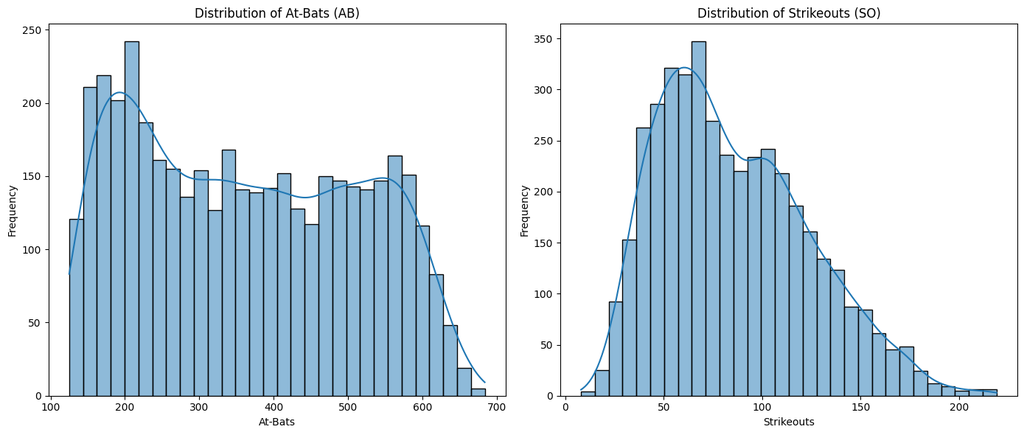

```python
# Plot distributions of key batting metrics (e.g., At-Bats and Strikeouts)
plt.figure(figsize=(14, 6))
plt.subplot(1, 2, 1)
sns.histplot(batting_data_reduced['AB'], bins=30, kde=True)
plt.title("Distribution of At-Bats (AB)")
plt.xlabel("At-Bats")
plt.ylabel("Frequency")

plt.subplot(1, 2, 2)
sns.histplot(batting_data_reduced['SO'], bins=30, kde=True)
plt.title("Distribution of Strikeouts (SO)")
plt.xlabel("Strikeouts")
plt.ylabel("Frequency")

plt.tight_layout()
plt.show()
```

### Distribution of At-Bats (AB) and Strikeouts (SO)

These visualizations help establish the variability and trends in offensive statistics, preparing us for deeper analysis of metrics like Runs Created Above Replacement (RCAR).

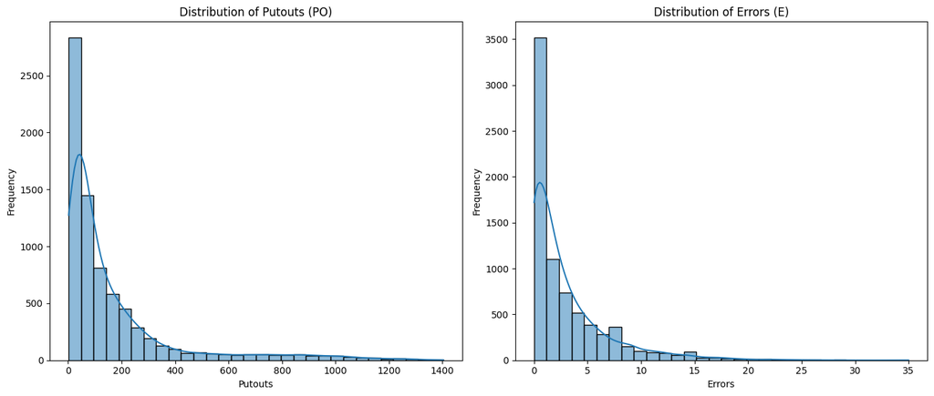

```python
# Plot distributions of key fielding metrics (e.g., Putouts and Errors)
plt.figure(figsize=(14, 6))
plt.subplot(1, 2, 1)
sns.histplot(fielding_data_reduced['PO'], bins=30, kde=True)
plt.title("Distribution of Putouts (PO)")
plt.xlabel("Putouts")
plt.ylabel("Frequency")

plt.subplot(1, 2, 2)
sns.histplot(fielding_data_reduced['E'], bins=30, kde=True)
plt.title("Distribution of Errors (E)")
plt.xlabel("Errors")
plt.ylabel("Frequency")

plt.tight_layout()
plt.show()
```

### Distribution of Putouts (PO) and Errors (E)

These visualizations highlight the defensive workload and challenges faced by players at various positions, laying the groundwork for metrics like Defensive Value Above Replacement (DVAR).

## Key Calculations for RCAR and DVAR

**Note**: In these formulas, "rp" denotes "replacement level," representing values at the 20th percentile for each metric.

```python
# Fresh dataframs for analysis
batting_df = batting_data_reduced.copy()
fielding_df = fielding_data_reduced.copy()
```

## Offensive Metrics

**Total Bases (TB)**: $$ TB = \text{Singles} + (2 \times \text{Doubles}) + (3 \times \text{Triples}) + (4 \times \text{Home Runs}) $$

```python
# Calculate Total Bases (TB) for RC formula
batting_df.loc[:, 'TB'] = (batting_df['1B'] +
                           2 * batting_df['2B'] +
                           3 * batting_df['3B'] +
                           4 * batting_df['HR'])
```

**Runs Created (RC)**: $$ RC = \frac{TB \times (H + BB)}{AB + BB} $$

```python
# Calculate Runs Created (RC) using the given formula
batting_df.loc[:, 'RC'] = (batting_df['TB'] * (batting_df['H'] + batting_df['BB'])) / (batting_df['AB'] + batting_df['BB'])
```

**Replacement-Level Runs Created (rpRC)**: $$ rpRC = \text{20th percentile of RC across all players} $$

```python
# Calculate replacement-level RC (rpRC) as the 20th percentile of RC
rpRC = batting_df['RC'].quantile(0.20)
```

**Run Contribution Above Replacement (RCAR)**: $$ RCAR = RC - rpRC $$

```python
# Calculate RCAR as RC minus replacement-level RC
batting_df.loc[:, 'RCAR'] = batting_df['RC'] - rpRC
```

```python
# Display sample calculations
print("\nSample RC and RCAR Calculations:")
print(batting_df[['Name', 'Season', 'RC', 'RCAR']].head())
```

```
Sample RC and RCAR Calculations:
                Name  Season          RC        RCAR
0         Mike Trout    2014  126.318248  103.389677
1       Buster Posey    2014   97.905724   74.977152
2   Andrew McCutchen    2014  120.303797   97.375226
3    Jonathan Lucroy    2014  101.112135   78.183564
4  Giancarlo Stanton    2014  117.616114   94.687542
```

## Defensive Metrics

**Range Factor (RF)**: $$ RF = \frac{PO + A}{G} $$

```python
# Calculate Range Factor (RF) for DVAR
fielding_df.loc[:, 'RF'] = (fielding_df['PO'] + fielding_df['A']) / fielding_df['G']
```

**Estimated Defensive Value (EDV)**: $$ EDV = (PO + A - E) + (0.5 \times RF) $$

```python
# Calculate Estimated Defensive Value (EDV)
fielding_df.loc[:, 'EDV'] = (fielding_df['PO'] + fielding_df['A'] - fielding_df['E']) + (0.5 * fielding_df['RF'])
```

**Replacement-Level Estimated Defensive Value (rpEDV)**: $$ rpEDV = \text{20th percentile of EDV across all players} $$

```python
# Calculate replacement-level EDV (rpEDV) as the 20th percentile of EDV
rpEDV = fielding_df['EDV'].quantile(0.20)
```

**Defensive Value Above Replacement (DVAR)**: $$ DVAR = EDV - rpEDV $$

```python
# Calculate DVAR as EDV minus replacement-level EDV
fielding_df.loc[:, 'DVAR'] = fielding_df['EDV'] - rpEDV
```

```python
# Display sample calculations
print("\nSample EDV and DVAR Calculations:")
print(fielding_df[['Name', 'Season', 'EDV', 'DVAR']].head())
```

```
Sample EDV and DVAR Calculations:
              Name  Season          EDV         DVAR
0      Rene Rivera    2014   742.191011   699.031362
1      Mike Zunino    2014  1093.207692  1050.048043
2  Jonathan Lucroy    2014  1077.963235  1034.803586
3   Miguel Montero    2014  1093.206107  1050.046458
4   Russell Martin    2014   874.088785   830.929136
```

```python
# Descriptive Statistics for RCAR and DVAR
rcar_stats = batting_df['RCAR'].describe(percentiles=[0.25, 0.5, 0.75])
dvar_stats = fielding_df['DVAR'].describe(percentiles=[0.25, 0.5, 0.75])

print("\nDescriptive Statistics for RCAR:")
print(rcar_stats)

print("\nDescriptive Statistics for DVAR:")
print(dvar_stats)
```

```
Descriptive Statistics for RCAR:
count    4216.000000
mean       26.646213
std        28.349386
min       -17.128571
25%         3.336782
50%        21.149838
75%        45.239458
max       154.377787
Name: RCAR, dtype: float64

Descriptive Statistics for DVAR:
count    7597.000000
mean      173.745548
std       252.580323
min       -33.838221
25%         8.583208
50%        70.797978
75%       235.993577
max      1457.620606
Name: DVAR, dtype: float64
```

## Unifying Batting and Fielding Data

To facilitate meaningful comparisons of player performance across positions, we unify the batting and fielding datasets into a single comprehensive dataset.

For players who field multiple positions, we assign each player to the position where they achieve their highest **DVAR** value. This assignment ensures that players are analyzed within the context of their primary defensive role, reflecting their most impactful contributions on the field.

```python
# Merge Batting and Fielding Data

# Select primary position by highest DVAR for each player in each season
# Prevents defensive duplicates for players that play multiple positions
# Keeps player at position with highest DVAR value
fielding_primary = fielding_df.sort_values('DVAR', ascending=False).drop_duplicates(['IDfg', 'Season'])

# # Merge batting and primary position fielding data on 'IDfg' and 'Season'
merged_df = pd.merge(
    batting_df,
    fielding_primary[['IDfg', 'Season', 'Pos', 'PO', 'A', 'E', 'DRS', 'Inn', 'G', 'DVAR']],
    on=['IDfg', 'Season'], how='inner')
```

```python
# Calculate Percentile Ranks by Position for RCAR and DVAR
merged_df['RCAR_percentile'] = merged_df.groupby('Pos')['RCAR'].rank(pct=True) * 100
merged_df['DVAR_percentile'] = merged_df.groupby('Pos')['DVAR'].rank(pct=True) * 100
```

```python
# Summary statistics by position for RCAR and DVAR
summary_stats = merged_df.groupby('Pos')[['RCAR', 'DVAR']].agg(['mean', 'median', 'std']).round(2)

# Display the summary statistics table
print("\nSummary Statistics by Position for RCAR and DVAR:")
print(summary_stats)
```

```
Summary Statistics by Position for RCAR and DVAR:
      RCAR                  DVAR
      mean median    std    mean  median     std
Pos
1B   32.27  26.65  29.89  527.14  396.11  395.88
2B   24.27  18.38  27.51  257.91  205.33  190.15
3B   32.27  29.91  31.03  169.47  162.44  108.51
C    12.46   7.95  19.55  601.62  578.11  249.50
CF   24.32  19.82  27.05  147.39  129.31   99.90
LF   26.68  21.76  26.48   78.97   59.16   69.85
RF   32.17  27.44  30.57  103.36   88.18   83.02
SS   29.36  26.56  26.64  313.29  322.85  178.13
```

```python
# Spot check to confirm calculations
print("\nSample RCAR and DVAR Percentile Ranks by Position:")
print(merged_df[['Name', 'Pos', 'RCAR', 'RCAR_percentile', 'DVAR', 'DVAR_percentile']].head())
```

```
Sample RCAR and DVAR Percentile Ranks by Position:
                Name Pos        RCAR  RCAR_percentile         DVAR  \
0         Mike Trout  CF  103.389677        98.611111   342.139009
1       Buster Posey   C   74.977152        99.309154   793.615126
2   Andrew McCutchen  CF   97.375226        98.412698   253.874597
3    Jonathan Lucroy   C   78.183564        99.827288  1034.803586
4  Giancarlo Stanton  RF   94.687542        96.680498   277.980211

   DVAR_percentile
0        97.222222
1        74.093264
2        82.341270
3        95.164076
4        98.547718
```

## Distributions of RCAR and DVAR

### Visualizing Offensive Metrics

- The distribution of RCAR highlights positional differences in offensive contributions.
- Outliers with exceptionally high RCAR scores are often elite hitters.

### Visualizing Defensive Metrics

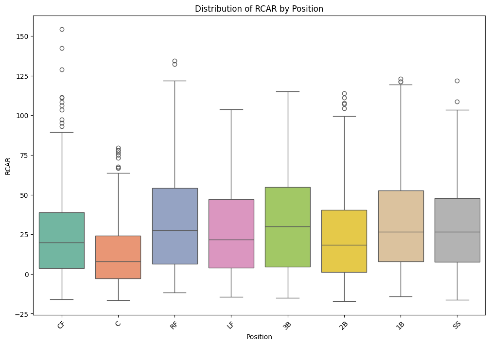

```python
# Visualize RCAR by Position with Boxplots
plt.figure(figsize=(12, 8))
sns.boxplot(x='Pos', y='RCAR', data=merged_df, palette='Set2', hue='Pos', dodge=False, legend=False)
plt.title("Distribution of RCAR by Position")
plt.xlabel("Position")
plt.ylabel("RCAR")
plt.xticks(rotation=45)
plt.legend([], [], frameon=False)  # Hide the legend explicitly
plt.show()
```

### Distribution of RCAR by Position

The boxplot above displays the distribution of **Runs Created Above Replacement (RCAR)** across various positions. RCAR measures offensive contributions relative to a replacement-level player, making it position-specific.

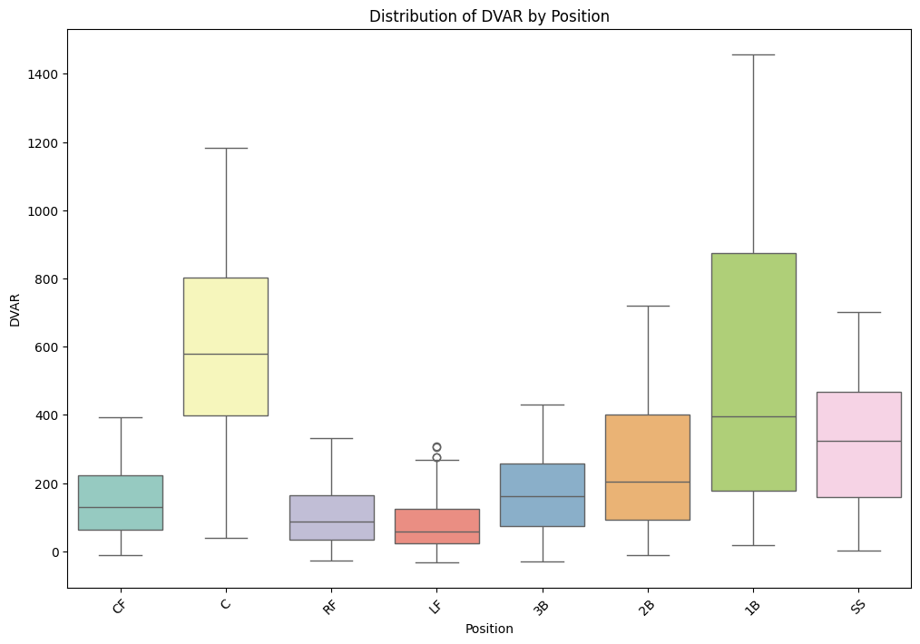

```python
# Visualize DVAR by Position with Boxplots
plt.figure(figsize=(12, 8))
sns.boxplot(x='Pos', y='DVAR', data=merged_df, palette='Set3', hue='Pos', dodge=False, legend=False)
plt.title("Distribution of DVAR by Position")
plt.xlabel("Position")
plt.ylabel("DVAR")
plt.xticks(rotation=45)
plt.legend([], [], frameon=False)  # Hide the legend explicitly
plt.show()
```

### Distribution of DVAR by Position

This boxplot illustrates the distribution of **Defensive Value Above Replacement (DVAR)** across various positions. DVAR quantifies defensive contributions relative to a replacement-level player, emphasizing the importance of fielding and defensive ability.

- **Central Tendencies**: Positions like Catcher (C) and First Base (1B) have higher median DVAR values, reflecting their critical defensive roles. However, it is worth nothing that many outs occur at First Base, and Catchers are credited with a putout after any strike-out. Our DVAR calculation could potentially be over-valuing these positions simply because they're involed in more outs than other positions.
- **Spread of Data**: The variability in DVAR is particularly high for Catcher (C) and First Base (1B), suggesting significant differences in defensive value here versus other positions.
- **Outliers**: The plot shows a few outliers in Left Field (LF), where some players outperform their positional peers significantly in defensive metrics.
- **Insights**: Positions like Shortstop (SS) and Second Base (2B) have moderate median DVAR values, aligning with their need for agility and defensive precision. Meanwhile, outfielders, particularly Right Field (RF) and Left Field (LF), tend to have a narrower range of defensive performance, highlighting their specialized defensive roles.

These visualizations provide a clear overview of how RCAR and DVAR distributions differ across positions, emphasizing the importance of evaluating players within their positional context to ensure fair comparisons.

## Analysis of Variance (ANOVA)

To validate the effectiveness of RCAR and DVAR as metrics for evaluating player performance across positions, we employ **Analysis of Variance (ANOVA)**. This statistical method tests whether the means of RCAR and DVAR differ significantly across player positions.

- **Objective**: Determine if the variability in RCAR and DVAR is explained by differences between positions, rather than random variation. If the test reveals significant differences, it supports the hypothesis that these metrics can effectively distinguish positional contributions.

### Why ANOVA is Appropriate Here

1. **Multiple Groups:** We are comparing RCAR and DVAR across multiple positions (e.g., CF, RF, SS), making ANOVA ideal for testing differences across more than two groups.
2. **Hypothesis Testing:** ANOVA allows us to validate our hypothesis that RCAR and DVAR effectively distinguish contributions across positions.
3. **Focusing on Variance:** By analyzing the ratio of between-group variance (differences between positions) to within-group variance (differences within a single position), ANOVA quantifies how much of the observed variability is due to positional differences.

### About `f_oneway`

- The `f_oneway` function from `scipy.stats` performs a **one-way ANOVA**.
- It calculates the **F-statistic**, which measures:
  - **Between-group variance**: How much the means differ between positions.
  - **Within-group variance**: How much variability exists within each position.
- The accompanying **p-value** indicates whether the observed differences are statistically significant.

### What ANOVA Will Tell Us

1. **RCAR ANOVA:**
   - Tests if the mean offensive contributions (RCAR) differ significantly by position.
   - A significant result (low p-value) would indicate that position plays a major role in offensive contributions.
2. **DVAR ANOVA:**
   - Tests if the mean defensive contributions (DVAR) differ significantly by position.
   - A significant result (low p-value) would indicate that position plays a major role in defensive contributions.

### Steps:

1. **Isolating Positions**:
   - Extract unique positions from the dataset to group player data by position (e.g., CF, RF, SS, etc.).
2. **RCAR ANOVA**:
   - Group RCAR values by position and perform ANOVA to assess whether the mean offensive contributions differ significantly across positions.
3. **DVAR ANOVA**:
   - Similarly, group DVAR values by position and perform ANOVA to evaluate differences in defensive contributions across positions.

### Expected Outcome:

- **F-statistic**: Indicates the ratio of between-group variance to within-group variance. A higher F-statistic suggests greater differences between positions relative to individual variability.
- **p-value**: A value below the threshold (e.g., 0.05) would confirm statistically significant differences in RCAR and/or DVAR across positions.

By conducting this ANOVA analysis, we aim to establish the validity of RCAR and DVAR as meaningful metrics that reflect position-specific player contributions in both offensive and defensive contexts.

```python
# Perform ANOVA on RCAR and DVAR by position

# Isolate positions
positions = merged_df['Pos'].unique()

# RCAR ANOVA
rcar_groups = [merged_df[merged_df['Pos'] == pos]['RCAR'] for pos in positions]
anova_rcar = f_oneway(*rcar_groups)

# DVAR ANOVA
dvar_groups = [merged_df[merged_df['Pos'] == pos]['DVAR'] for pos in positions]
anova_dvar = f_oneway(*dvar_groups)
```

```python
# Display ANOVA results
print("ANOVA Results for RCAR by Position:")
print(f"F-statistic: {anova_rcar.statistic:.2f}, p-value: {anova_rcar.pvalue:.4f}")

print("\nANOVA Results for DVAR by Position:")
print(f"F-statistic: {anova_dvar.statistic:.2f}, p-value: {anova_dvar.pvalue:.4f}")
```

```
ANOVA Results for RCAR by Position:
F-statistic: 33.14, p-value: 0.0000

ANOVA Results for DVAR by Position:
F-statistic: 460.17, p-value: 0.0000
```

### Results:

1. **RCAR by Position:**
   - F-statistic: **33.14**
   - p-value: **0.0000**
   - Interpretation: Offensive contributions (RCAR) differ significantly by position.
2. **DVAR by Position:**
   - F-statistic: **460.17**
   - p-value: **0.0000**
   - Interpretation: Defensive contributions (DVAR) differ significantly by position.

These results confirm that player performance varies significantly across positions.

## Comparing RCAR and DVAR Against Established Metrics

### Introduction

To validate the effectiveness of our custom metrics, RCAR (Runs Created Above Replacement) and DVAR (Defensive Value Above Replacement), we compare them against well-established baseball statistics: WAR (Wins Above Replacement) for offensive contributions and DRS (Defensive Runs Saved) for defensive value. These comparisons provide insight into the reliability and potential alignment of RCAR and DVAR with existing standards.

### Methodology

1. **RCAR vs. WAR:**
   - We calculate the Pearson correlation coefficient between RCAR and WAR to evaluate their relationship.
   - A high correlation would indicate that RCAR effectively captures offensive contributions similar to WAR.
2. **DVAR vs. DRS:**
   - We compute the Pearson correlation coefficient between DVAR and DRS to assess their alignment.
   - Given the methodological differences between DVAR and DRS, a lower correlation is anticipated but still worth exploring.
3. **Visualization:**
   - Scatter plots are used to visually examine the relationship between the metrics:
     - RCAR vs. WAR
     - DVAR vs. DRS
   - These plots help identify trends and outliers.

### About Pearson Correlation Coefficient (`pearsonr`)

The Pearson correlation coefficient measures the linear relationship between two variables, with values ranging from -1 to 1:

- **1:** Perfect positive correlation, where increases in one variable correspond to proportional increases in the other.
- **-1:** Perfect negative correlation, where increases in one variable correspond to proportional decreases in the other.
- **0:** No linear relationship between the variables.

```
RCAR vs. WAR Correlation: 0.81, p-value: 0.0000
DVAR vs. DRS Correlation: 0.13, p-value: 0.0000
```

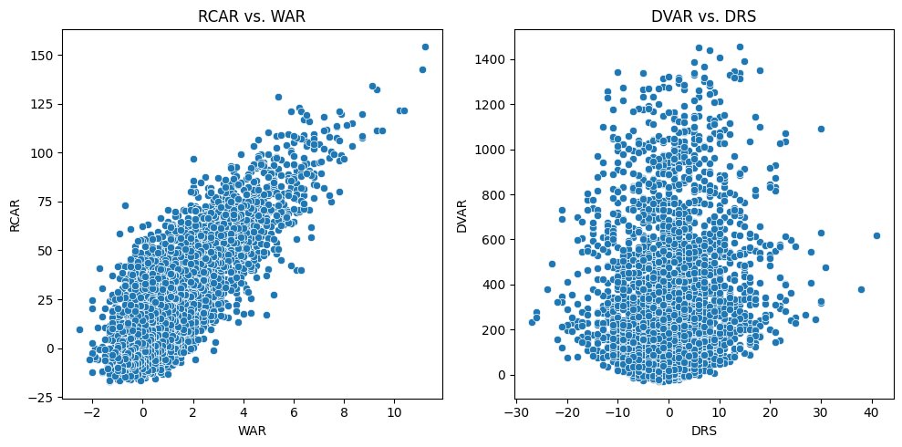

```python
# Compare RCAR against WAR
rcar_war_corr, rcar_war_pval = pearsonr(merged_df['RCAR'], merged_df['WAR'])
print(f"RCAR vs. WAR Correlation: {rcar_war_corr:.2f}, p-value: {rcar_war_pval:.4f}")

# Compare DVAR against DRS
dvar_drs_corr, dvar_drs_pval = pearsonr(merged_df['DVAR'], merged_df['DRS'])
print(f"DVAR vs. DRS Correlation: {dvar_drs_corr:.2f}, p-value: {dvar_drs_pval:.4f}")

# Visualize scatter plots for correlations
plt.figure(figsize=(10, 5))

# Scatter plot for RCAR vs. WAR
plt.subplot(1, 2, 1)
sns.scatterplot(x='WAR', y='RCAR', data=merged_df)
plt.title("RCAR vs. WAR")
plt.xlabel("WAR")
plt.ylabel("RCAR")

# Scatter plot for DVAR vs. DRS
plt.subplot(1, 2, 2)
sns.scatterplot(x='DRS', y='DVAR', data=merged_df)
plt.title("DVAR vs. DRS")
plt.xlabel("DRS")
plt.ylabel("DVAR")

plt.tight_layout()
plt.show()
```

## Correlation to Established Metrics:

### RCAR vs. WAR:

- Correlation: **0.81**
- Interpretation: RCAR aligns closely with WAR, indicating it is a reliable measure of offensive contributions.

### DVAR vs. DRS:

- Correlation: **0.13**
- Interpretation: DVAR has a weak correlation with DRS, reflecting differences in methodology. DVAR incorporates range factor and error penalties, while DRS uses advanced fielding models.
- DVAR appears to over-value certain certain metrics opposed to DRS, meaning it may not be the most reliable measure of player value.

## Post-ANOVA Visual Analysis: RCAR and DVAR by Position with Means and Confidence Intervals

### Confidence Intervals and Positional Comparisons

To further analyze RCAR and DVAR across player positions, we calculate the mean and 95% confidence intervals for each position. Confidence intervals provide a measure of uncertainty around the mean, helping us assess the consistency of player contributions within a position.

The following visualizations combine boxplots of RCAR and DVAR distributions with overlaid confidence intervals, offering a deeper understanding of positional trends and variability in offensive and defensive contributions.

```python
# Calculate means and confidence intervals for RCAR and DVAR by position
position_summary = merged_df.groupby('Pos').agg(
    RCAR_mean=('RCAR', 'mean'),
    RCAR_std=('RCAR', 'std'),
    DVAR_mean=('DVAR', 'mean'),
    DVAR_std=('DVAR', 'std'),
    count=('RCAR', 'size')
)
position_summary['RCAR_CI'] = 1.96 * position_summary['RCAR_std'] / np.sqrt(position_summary['count'])
position_summary['DVAR_CI'] = 1.96 * position_summary['DVAR_std'] / np.sqrt(position_summary['count'])
```

[figure not shown]

```python
# Plot RCAR boxplot with mean and confidence interval lines
plt.figure(figsize=(12, 8))
sns.boxplot(x='Pos', y='RCAR', data=merged_df, palette='Set2', hue='Pos', dodge=False, legend=False)
plt.title("Distribution of RCAR by Position with Mean and 95% CI")
plt.xlabel("Position")
plt.ylabel("RCAR")

# Overlay mean and confidence intervals
for i, pos in enumerate(position_summary.index):
    plt.hlines(y=position_summary.loc[pos, 'RCAR_mean'], xmin=i - 0.4, xmax=i + 0.4, color='blue', linestyle='--')
    plt.fill_betweenx(
        y=[position_summary.loc[pos, 'RCAR_mean'] - position_summary.loc[pos, 'RCAR_CI'],
           position_summary.loc[pos, 'RCAR_mean'] + position_summary.loc[pos, 'RCAR_CI']],
        x1=i - 0.3, x2=i + 0.3, color='blue', alpha=0.2
    )

plt.show()
```

#### RCAR (Runs Created Above Replacement) Distribution by Position

This boxplot illustrates the distribution of RCAR across player positions. Each box represents the interquartile range (IQR), with the horizontal line inside the box indicating the median RCAR for that position. The whiskers extend to 1.5 times the IQR, and individual points beyond the whiskers are outliers.

Key elements:

- **Dashed blue lines:** Represent the mean RCAR for each position.
- **Shaded blue areas around the dashed lines:** Depict the 95% confidence interval for the mean, calculated based on the sample size and standard deviation for each position.

[figure not shown]

```python
# Plot DVAR boxplot with mean and confidence interval lines
plt.figure(figsize=(12, 8))
sns.boxplot(x='Pos', y='DVAR', data=merged_df, palette='Set3', hue='Pos', dodge=False, legend=False)
plt.title("Distribution of DVAR by Position with Mean and 95% CI")
plt.xlabel("Position")
plt.ylabel("DVAR")

# Overlay mean and confidence intervals
for i, pos in enumerate(position_summary.index):
    plt.hlines(y=position_summary.loc[pos, 'DVAR_mean'], xmin=i - 0.4, xmax=i + 0.4, color='green', linestyle='--')
    plt.fill_betweenx(
        y=[position_summary.loc[pos, 'DVAR_mean'] - position_summary.loc[pos, 'DVAR_CI'],
           position_summary.loc[pos, 'DVAR_mean'] + position_summary.loc[pos, 'DVAR_CI']],
        x1=i - 0.3, x2=i + 0.3, color='green', alpha=0.2
    )

plt.show()
```

#### DVAR (Defensive Value Above Replacement) Distribution by Position

This boxplot highlights the distribution of DVAR across player positions. As with the RCAR plot, the boxes represent the IQR, medians are marked with solid lines, and outliers are shown as individual points.

Key elements:

- **Dashed green lines:** Indicate the mean DVAR for each position.
- **Shaded green areas around the dashed lines:** Represent the 95% confidence intervals for the mean.

**Interpretation:**

- **Catcher (C):** Shows the highest median and mean DVAR, underscoring the significant defensive contributions of catchers compared to other positions. The wide confidence interval suggests variability in catcher performance.
- **First Base (1B):** Exhibits a wide range of DVAR values, with a high mean but significant variability, indicating that defensive value can vary considerably for this position.
- **Shortstop (SS) and Center Field (CF):** Show relatively balanced distributions, with moderate means and narrower confidence intervals, reflecting consistent defensive contributions.
- **Outfield positions (RF and LF):** Have narrower distributions and lower mean DVAR values, suggesting less variability and lower overall defensive impact compared to infield positions.

### Summary of Insights

These findings align with traditional baseball knowledge in many ways, and provide robust support for the validity of RCAR and DVAR as metrics tailored to position-specific evaluations.

## Identifying Top 10 Players by Offensive and Defensive Metrics

To highlight individual player performance, we identify the top 10 players for each season based on RCAR (offensive contributions) and DVAR (defensive contributions). These rankings allow us to pinpoint players who excel relative to their peers at their positions, providing actionable insights for scouting, lineup optimization, and player evaluation.

The results will be displayed and visualized to showcase the standout performers across seasons.

```python
# Define a function to return the top 10 players by a metric
def get_top_10_by_metric(dataframe, metric, season):
    """
    Returns the top 10 players for a given metric and season.

    Parameters:
        dataframe (pd.DataFrame): The DataFrame containing player data.
        metric (str): The metric to rank players by (e.g., 'RCAR' or 'DVAR').
        season (int): The season year to filter by.

    Returns:
        pd.DataFrame: A DataFrame of the top 10 players for the specified metric and season.
    """
    # Filter data for the given season
    season_data = dataframe[dataframe['Season'] == season]

    # Sort by the specified metric percentile and get the top 10
    top_10 = (
        season_data.sort_values(by=f'{metric}_percentile', ascending=False)
        .head(10)
    )

    return top_10[['Name', 'Pos', metric, f'{metric}_percentile', 'Season']]
```

```python
# Example usage for RCAR in the 2024 season
print("Top 10 Players Based on RCAR in 2024:")
top_10_rcar_2024 = get_top_10_by_metric(merged_df, 'RCAR', 2024)
print(top_10_rcar_2024)

# Example usage for DVAR in the 2024 season
print("\nTop 10 Players Based on DVAR in 2024:")
top_10_dvar_2024 = get_top_10_by_metric(merged_df, 'DVAR', 2024)
print(top_10_dvar_2024)
```

```
Top 10 Players Based on RCAR in 2024:
                       Name Pos        RCAR  RCAR_percentile  Season
3743            Aaron Judge  CF  154.377787       100.000000    2024
3744         Bobby Witt Jr.  SS  121.706349       100.000000    2024
3754      William Contreras   C   77.910953        99.654577    2024
3756         Yordan Alvarez  LF   97.533586        99.570815    2024
3746       Gunnar Henderson  SS   97.007869        99.130435    2024
3752  Vladimir Guerrero Jr.  1B  109.026370        98.793363    2024
3745              Juan Soto  RF  114.319656        98.547718    2024
3800         Salvador Perez   C   63.626634        98.272884    2024
3804            Yainer Diaz   C   61.376847        97.582038    2024
3748           Jarren Duran  CF   88.588670        97.420635    2024

Top 10 Players Based on DVAR in 2024:
                 Name Pos         DVAR  DVAR_percentile  Season
3783    Brenton Doyle  CF   388.326652        99.801587    2024
3787         Ian Happ  LF   274.944518        99.356223    2024
3755      Cal Raleigh   C  1144.244055        99.309154    2024
3828      Taylor Ward  LF   262.939642        98.927039    2024
3784   Ezequiel Tovar  SS   618.967739        98.913043    2024
3757  Jackson Merrill  CF   355.130673        98.611111    2024
3805      J.J. Bleday  CF   353.114236        98.412698    2024
3985     Alex Verdugo  LF   231.815528        97.854077    2024
3835      Jacob Young  CF   343.159143        97.420635    2024
3832       Matt Olson  1B  1319.050227        97.285068    2024
```

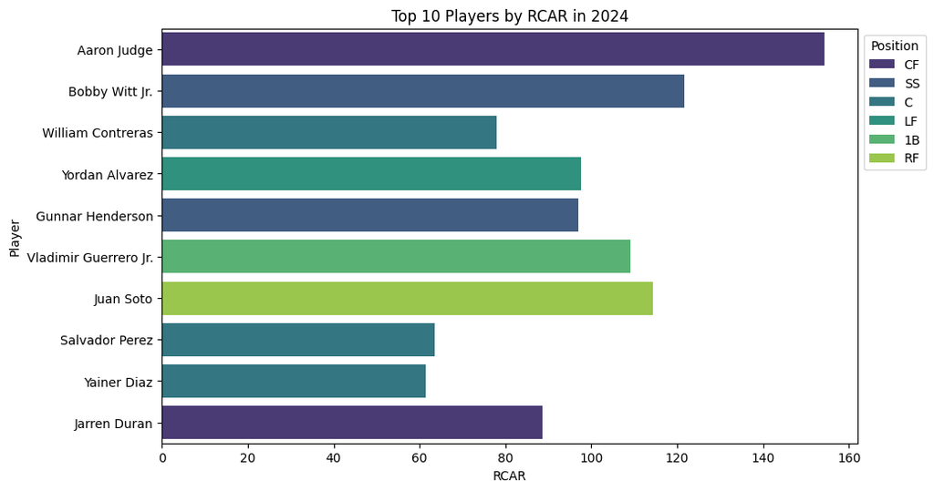

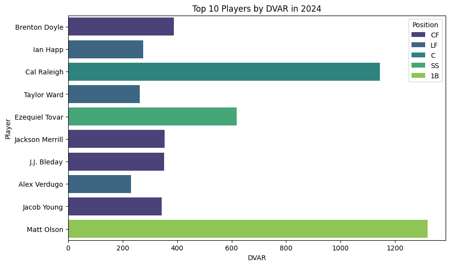

```python
# Plot top 10 Players for a given season

def plot_top_10_players(metric, season):
    top_10 = get_top_10_by_metric(merged_df, metric, season)
    plt.figure(figsize=(10, 6))
    sns.barplot(x=metric, y='Name', data=top_10, hue='Pos', dodge=False, palette='viridis')
    plt.title(f"Top 10 Players by {metric} in {season}")
    plt.xlabel(metric)
    plt.ylabel("Player")
    plt.legend(title="Position", bbox_to_anchor=(1, 1))
    plt.show()

# Example plots for 2024 season
plot_top_10_players('RCAR', 2024)
plot_top_10_players('DVAR', 2024)
```

### Observations from Top 10 Players by RCAR and DVAR in 2024

#### RCAR (Run Contribution Above Replacement) Analysis:

- The **Top 10 players by RCAR** highlight offensive performance across multiple positions.
- **Aaron Judge** stands out with a commanding RCAR score, leading by a significant margin, reflecting his offensive dominance in the league.
- Players from various positions, including **Bobby Witt Jr. (SS)** and **Juan Soto (RF)**, demonstrate the versatility and distribution of top offensive contributors across the field.
- Catchers such as **William Contreras** and **Yainer Diaz** also rank in the top 10, indicating that even traditionally less offensive positions can produce impactful players in specific seasons.
- The diverse mix of positions underscores the fairness of RCAR in comparing players within their roles without over-favoring one position.

### Key Takeaways:

- Both RCAR and DVAR provide complementary perspectives on player value, addressing offense and defense independently.
- These visualizations demonstrate how players at every position contribute uniquely to team success, emphasizing the importance of metrics tailored to position-specific responsibilities.
- The plots validate the metrics' ability to identify standout players in both dimensions of the game, supporting their potential utility for analysts and coaches.
- DVAR seems to value First Base **(1B)** and Catcher **(C)** more than other positions, shown by **Raleigh** and **Olson's** very high scores compared to other positions.

## Analyzing Average Percentile Ranks for RCAR and DVAR by Position

To better understand the relative offensive and defensive contributions of players at different positions, we calculated the average RCAR (offensive) and DVAR (defensive) percentiles for each position. Percentile ranks provide a normalized view of player performance, allowing for direct comparison across positions.

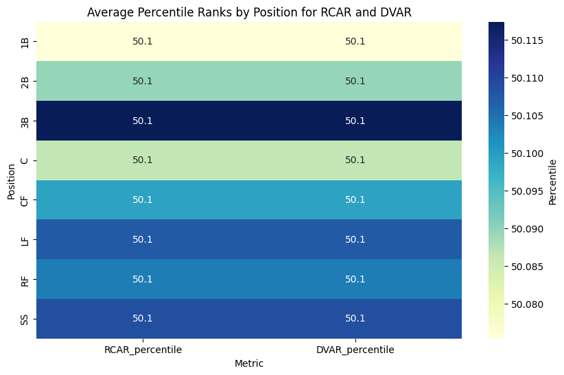

```python
# Calculate average RCAR and DVAR percentiles by position
percentile_summary = merged_df.groupby('Pos')[['RCAR_percentile', 'DVAR_percentile']].mean()

# Heatmap of Percentile Ranks by Position
plt.figure(figsize=(10, 6))
sns.heatmap(percentile_summary, annot=True, cmap="YlGnBu", fmt=".1f", cbar_kws={'label': 'Percentile'})
plt.title("Average Percentile Ranks by Position for RCAR and DVAR")
plt.xlabel("Metric")
plt.ylabel("Position")
plt.show()
```

#### Key Observations:

- The heatmap displays a striking uniformity in percentile ranks across positions for both RCAR and DVAR, suggesting that percentile normalization effectively balances positional distributions. However, this balance may mask overvaluation of certain positions in terms of raw scores.
- While RCAR aligns with expectations—highlighting offensive contributions evenly across positions—DVAR’s uniform percentiles do not account for potentially inflated raw defensive values for positions like catcher (C) and first base (1B).
- This visualization underscores how percentile-based rankings can equalize performance across positions but may fail to highlight underlying metric imbalances.

#### Takeaways:

- To further explore positional disparities, it would be helpful to examine raw DVAR values by position. This could provide clarity on whether catchers and first basemen are disproportionately benefiting from the DVAR calculation.
- While percentile normalization is a useful tool for comparisons, it is crucial to ensure that underlying positional baselines and raw score distributions are consistent with the intended fairness of the metric.

This heatmap provides a useful overview of relative performance but also raises questions about whether DVAR’s underlying calculations align with true positional expectations. Further analysis of absolute scores is recommended to confirm or refute any positional overvaluation.

## Position-Specific Analysis of RCAR and DVAR

This section provides a closer look at the RCAR and DVAR metrics for individual positions, using specific seasons as examples. By isolating positions, we can better understand the distribution and key contributors within each group. For this analysis, we examine Shortstops (SS) in 2024, First Basemen (1B) in 2023, and Right Fielders (RF) in 2024.

#### Key Steps:

1. **Summary Statistics**: Descriptive statistics, such as mean, median, and standard deviation, are calculated to summarize RCAR and DVAR values for players within a given position and season. These provide a snapshot of overall performance trends and variability.
2. **Top 10 Players**: For each position and season, the top 10 players are identified and visualized using bar plots. Separate rankings are created for RCAR (offensive contribution) and DVAR (defensive contribution). These rankings highlight standout players and their relative impact.
3. **Insights by Position**: This approach allows us to pinpoint which players lead in offensive and defensive metrics within a positional context, offering insights into how roles and responsibilities might shape these contributions.

```python
# Analyze Individual Positions:

def analyze_position(dataframe, position, season):
    """
    Analyzes RCAR and DVAR for a specific position in a given season.

    Parameters:
        dataframe (pd.DataFrame): The dataset containing player data.
        position (str): The position to analyze (e.g., '1B', 'C').
        season (int): The season year to filter by.

    Returns:
        None
    """
    # Filter the data for the specified position and season
    position_data = dataframe[(dataframe['Pos'] == position) & (dataframe['Season'] == season)]

    # Display summary statistics for RCAR and DVAR within the position and season
    position_summary = position_data[['RCAR', 'DVAR']].describe()
    print(f"\nSummary Statistics for {position} in {season}:")
    print(position_summary)

    # Top 10 players by RCAR in the specified season and position
    top_rcar = position_data.sort_values(by='RCAR', ascending=False).head(10)
    # Plot top 10 players by RCAR
    plt.figure(figsize=(10, 6))
    sns.barplot(x='RCAR', y='Name', data=top_rcar, hue='Name', dodge=False, palette='Blues_d', legend=False)
    plt.title(f"Top 10 Players in {position} by RCAR in {season}")
    plt.xlabel("RCAR")
    plt.ylabel("Player")
    plt.show()

    # Top 10 players by DVAR in the specified season and position
    top_dvar = position_data.sort_values(by='DVAR', ascending=False).head(10)
    # Plot top 10 players by DVAR
    plt.figure(figsize=(10, 6))
    sns.barplot(x='DVAR', y='Name', data=top_dvar, hue='Name', dodge=False, palette='Greens_d', legend=False)
    plt.title(f"Top 10 Players in {position} by DVAR in {season}")
    plt.xlabel("DVAR")
    plt.ylabel("Player")
    plt.show()
```

```
Summary Statistics for SS in 2024:
             RCAR        DVAR
count   46.000000   46.000000
mean    29.894035  283.318405
std     30.803942  176.743081
min    -10.393302    5.440351
25%      5.346871  148.663149
50%     24.185755  233.517616
75%     48.460543  453.577607
max    121.706349  618.967739
```

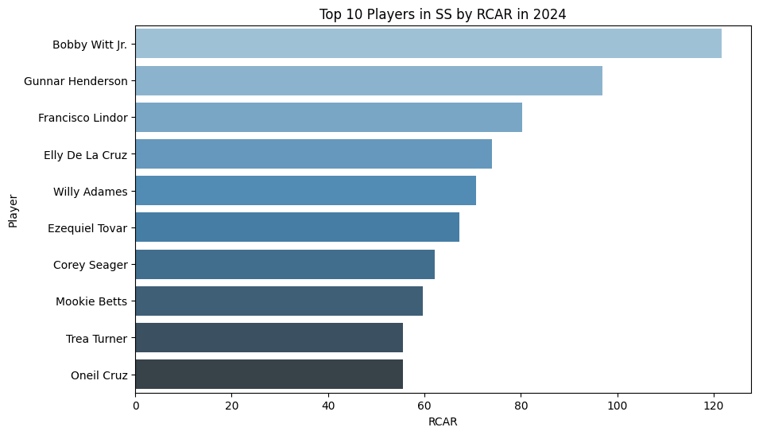

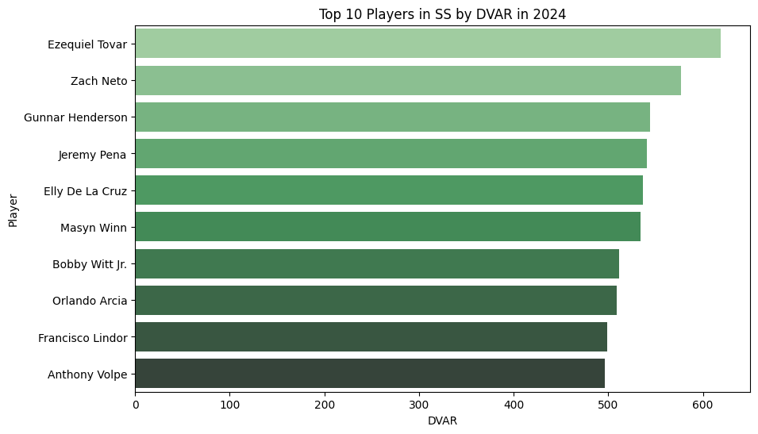

```python
# Analyze 2024 Shortstops
analyze_position(merged_df, 'SS', 2024)
```

#### Shortstop (SS) Analysis - 2024

- **Summary**: Shortstops in 2024 exhibit a broad range of RCAR and DVAR values, with RCAR values spanning from -10.39 to 121.71 and DVAR values ranging from 5.44 to 618.97.
- **Top Contributors**:
  - **RCAR**: **Bobby Witt Jr.** leads offensively, with **Gunnar Henderson** and **Francisco Lindor** close behind.
  - **DVAR**: **Ezequiel Tovar** dominates defensively, followed by **Zach Neto** and **Gunnar Henderson**.

```
Summary Statistics for 1B in 2023:
             RCAR         DVAR
count   59.000000    59.000000
mean    35.793049   525.883602
std     29.803531   384.785170
min    -14.186850    30.571120
25%     10.184618   201.549062
50%     35.145963   411.958533
75%     55.141954   886.285456
max    121.165928  1284.961469
```

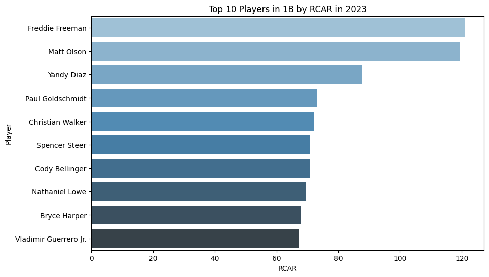

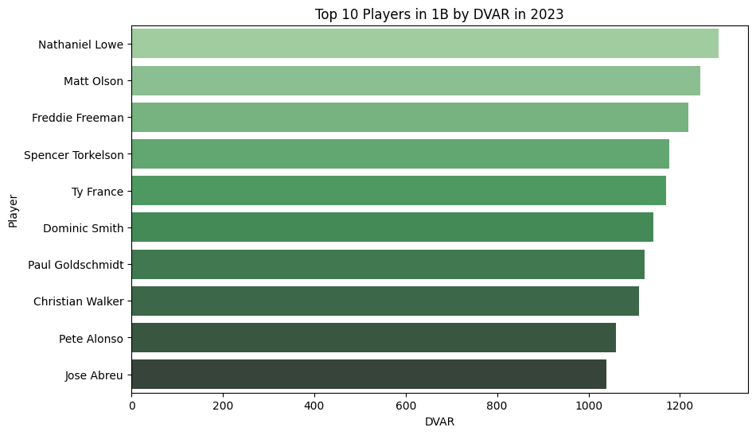

```python
# Analyze 2023 1st Basemen
analyze_position(merged_df, '1B', 2023)
```

#### First Baseman (1B) Analysis - 2023

```
Summary Statistics for RF in 2024:
             RCAR        DVAR
count   54.000000   54.000000
mean    20.227157   82.895271
std     24.097151   73.080250
min    -11.542433  -26.432376
25%      0.736454   29.798412
50%     18.681285   63.928886
75%     35.438886  132.711596
max    114.319656  253.867937
```

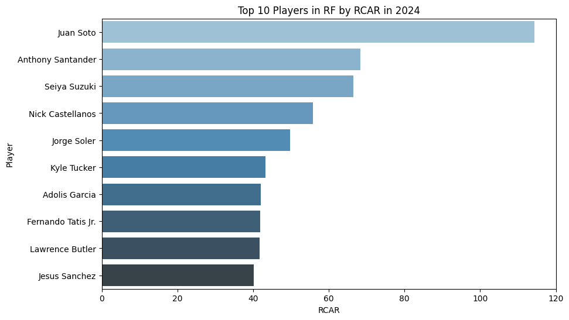

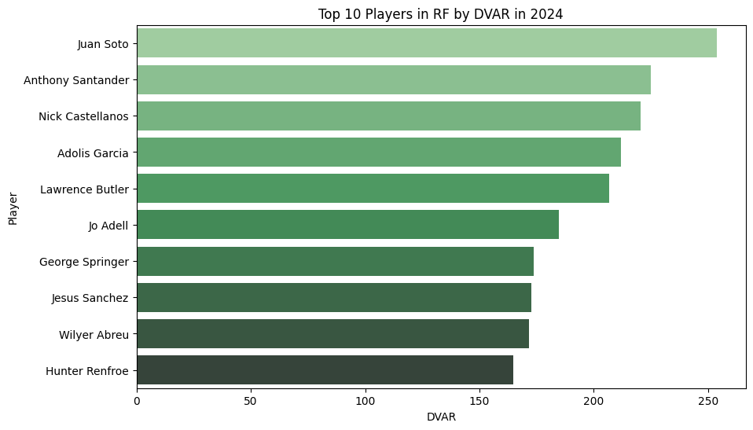

```python
# Analyze 2024 Right Fielders
analyze_position(merged_df, 'RF', 2024)
```

## Central Tendency, Variability, & Confidence Intervals

In this section, we aim to visualize the central tendencies and variability of RCAR (Run Contribution Above Replacement) and DVAR (Defensive Value Above Replacement) across player positions. By calculating and plotting the mean values alongside 95% confidence intervals, we provide a clearer understanding of how these metrics vary between positions, while also addressing the statistical uncertainty around the observed averages.

The inclusion of confidence intervals allows us to:

1. **Quantify Variability**: Highlight the level of uncertainty in the mean values, which can be influenced by sample size and variability within each position.
2. **Facilitate Comparisons**: Show how positions differ in their offensive (RCAR) and defensive (DVAR) contributions on average, while accounting for overlap between confidence intervals to indicate significant differences.
3. **Support Decision-Making**: Identify positions with higher variability or extreme values, which might indicate unique demands or player specialization.

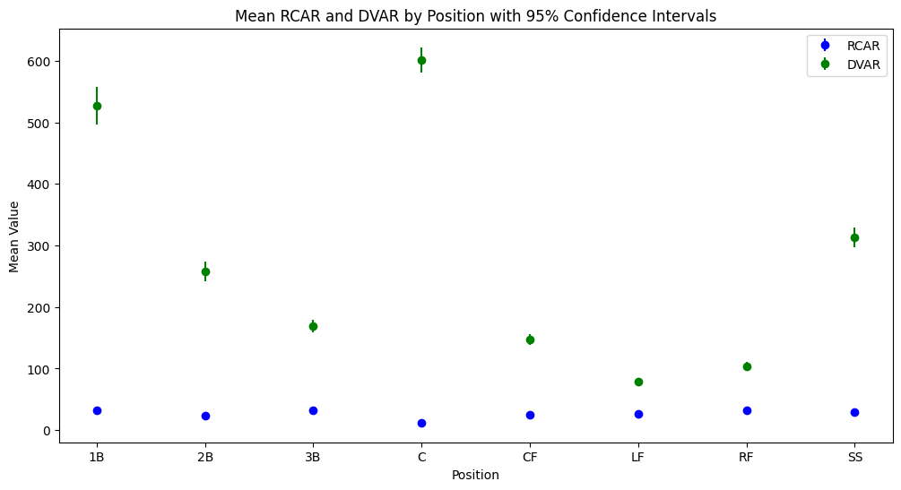

```python
import numpy as np

# Calculate means and confidence intervals for RCAR and DVAR by position
summary_df = merged_df.groupby('Pos').agg(
    RCAR_mean=('RCAR', 'mean'),
    RCAR_std=('RCAR', 'std'),
    DVAR_mean=('DVAR', 'mean'),
    DVAR_std=('DVAR', 'std')
)

# Calculate confidence intervals (using 1.96 * std / sqrt(n) for 95% CI)
summary_df['RCAR_CI'] = 1.96 * summary_df['RCAR_std'] / np.sqrt(merged_df.groupby('Pos').size())
summary_df['DVAR_CI'] = 1.96 * summary_df['DVAR_std'] / np.sqrt(merged_df.groupby('Pos').size())

# Plot means with error bars
plt.figure(figsize=(12, 6))
plt.errorbar(summary_df.index, summary_df['RCAR_mean'], yerr=summary_df['RCAR_CI'], fmt='o', label='RCAR', color='blue')
plt.errorbar(summary_df.index, summary_df['DVAR_mean'], yerr=summary_df['DVAR_CI'], fmt='o', label='DVAR', color='green')
plt.title("Mean RCAR and DVAR by Position with 95% Confidence Intervals")
plt.xlabel("Position")
plt.ylabel("Mean Value")
plt.legend()
plt.show()
```

### Takeaways:

- RCAR aligns well with expectations and provides a fair representation of offensive contributions across positions.
- DVAR highlights some concerns regarding positional overvaluation, particularly for catchers and first basemen, which may require adjustments in the calculation to better reflect defensive difficulty and impact.
- Further investigation into DVAR’s weighting of specific defensive actions (e.g., putouts) is recommended to ensure it accurately represents true defensive contributions.

This analysis reinforces RCAR’s reliability while pointing to potential refinements for DVAR to improve its alignment with positional expectations and demands.

## Density Plots for RCAR and DVAR by Position

Density plots are a powerful way to visualize the distribution of a continuous variable across different groups. In this section, we explore the distributions of **RCAR (Run Contribution Above Replacement)** and **DVAR (Defensive Value Above Replacement)** for players, broken down by position. These plots provide an intuitive view of how offensive and defensive contributions vary across positions, highlighting trends and outliers that may not be immediately evident in summary statistics.

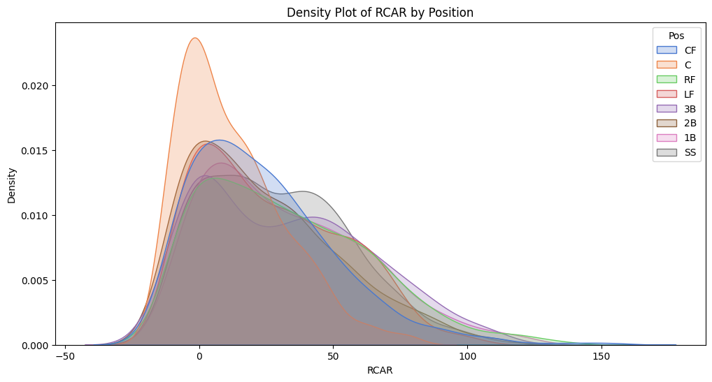

```python
# Density plot for RCAR by position
plt.figure(figsize=(12, 6))
sns.kdeplot(data=merged_df, x='RCAR', hue='Pos', common_norm=False, fill=True, palette='muted')
plt.title("Density Plot of RCAR by Position")
plt.xlabel("RCAR")
plt.ylabel("Density")
plt.show()
```

### RCAR Density Plot by Position

The density plot above illustrates the distribution of **Runs Created Above Replacement (RCAR)** across different positions.

#### Key Observations:

1. **Catchers (C)**: Show a distinct peak at lower RCAR values, reflecting their primary focus on defensive contributions rather than offense.
2. **Corner Positions (1B, LF, RF)**: Display broader distributions with higher RCAR values, consistent with their traditionally offensive roles.
3. **Middle Infielders (SS, 2B)**: Tend to cluster around moderate RCAR values, balancing their dual roles in offense and defense.
4. **General Spread**: The overall distribution of RCAR aligns with positional expectations, with positions like 1B and RF showing a heavier tail toward higher offensive contributions.

This visualization supports the conclusion that RCAR appropriately captures offensive differences across positions, with minimal distortion.

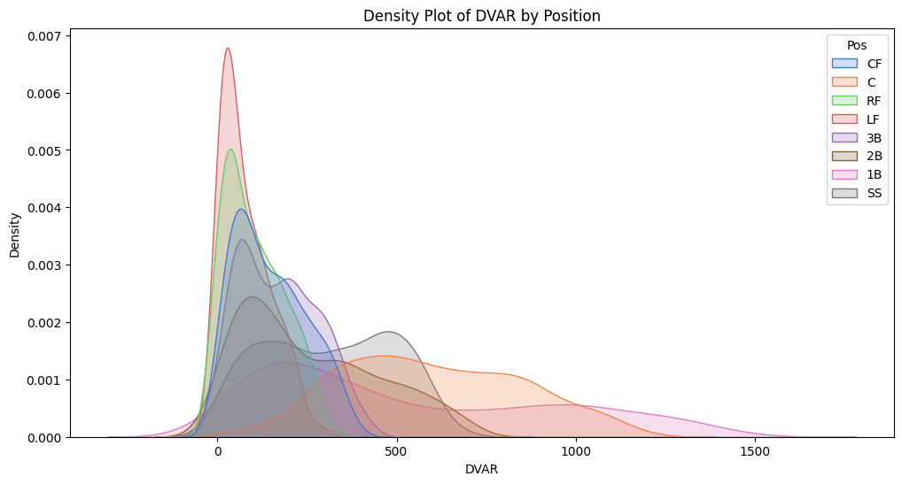

```python
# Density plot for DVAR by position
plt.figure(figsize=(12, 6))
sns.kdeplot(data=merged_df, x='DVAR', hue='Pos', common_norm=False, fill=True, palette='muted')
plt.title("Density Plot of DVAR by Position")
plt.xlabel("DVAR")
plt.ylabel("Density")
plt.show()
```

### DVAR Density Plot by Position

The density plot above visualizes the distribution of **Defensive Value Above Replacement (DVAR)** by position.

#### Key Observations:

This plot highlights a potential overemphasis on positions like **catcher and first base** in the current DVAR calculation, suggesting a need for refinement to better reflect defensive impact across all positions.

## Heatmaps for RCAR and DVAR by Season and Position

This section visualizes **Runs Created Above Replacement (RCAR)** and **Defensive Value Above Replacement (DVAR)** across positions over multiple seasons using heatmaps. These visualizations provide insights into positional trends over time and allow for the identification of patterns and anomalies in player performance.

The heatmaps help us:

1. **Highlight temporal trends**: Observe changes in positional contributions seasonally.
2. **Compare positions**: Determine which positions perform consistently well or poorly.
3. **Spot anomalies**: Identify seasons with significant deviations, such as the shortened 2020 season.
- **Note:** The 2020 MLB season was shortened due to the COVID-19 Pandemic, so it's values will be lower.

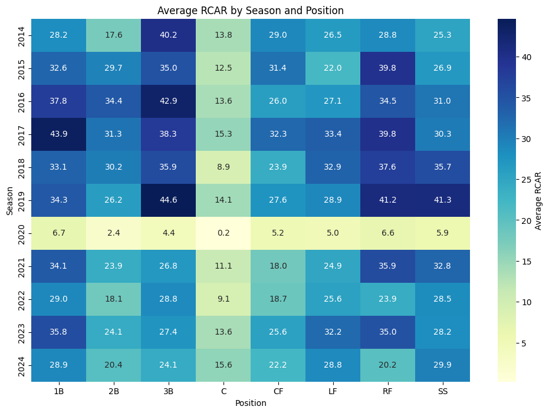

```python
# Create pivot tables for RCAR and DVAR
rcar_pivot = merged_df.pivot_table(index='Season', columns='Pos', values='RCAR', aggfunc='mean')
dvar_pivot = merged_df.pivot_table(index='Season', columns='Pos', values='DVAR', aggfunc='mean')

# Heatmap for RCAR
plt.figure(figsize=(12, 8))
sns.heatmap(rcar_pivot, annot=True, fmt=".1f", cmap="YlGnBu", cbar_kws={'label': 'Average RCAR'})
plt.title("Average RCAR by Season and Position")
plt.xlabel("Position")
plt.ylabel("Season")
plt.show()
```

#### Findings: RCAR Heatmap

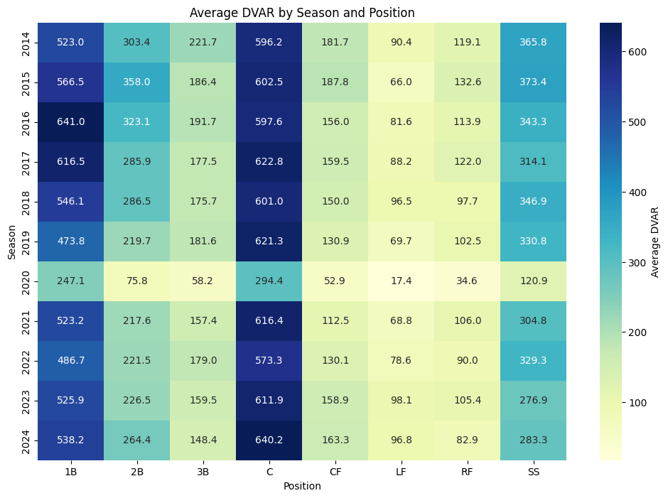

```python
# Heatmap for DVAR
plt.figure(figsize=(12, 8))
sns.heatmap(dvar_pivot, annot=True, fmt=".1f", cmap="YlGnBu", cbar_kws={'label': 'Average DVAR'})
plt.title("Average DVAR by Season and Position")
plt.xlabel("Position")
plt.ylabel("Season")
plt.show()
```

#### Importance

The RCAR and DVAR heatmaps provide a **season-by-season overview of positional contributions**:

- **RCAR** accurately reflects offensive production trends, aligning with expected positional roles and contributions.
- **DVAR**, while capturing defensive trends, may overemphasize the contributions of **catchers** and **first basemen**, potentially skewing positional comparisons.
- These visualizations allow for **comparative analysis** and contextual evaluations of offensive and defensive value, revealing both the strengths and limitations of the calculated metrics.

By aligning these findings with observed trends and the limitations in metric design, the heatmaps offer a valuable lens for understanding positional strengths across MLB seasons.

## Player Metric Trends Over Time: RCAR and DVAR

### Introduction

In this section, we analyze the trends in RCAR (Runs Created Above Replacement) and DVAR (Defensive Value Above Replacement) for individual players across seasons. By visualizing these metrics over time, we aim to uncover patterns in their offensive and defensive contributions and assess their consistency and variability throughout their careers.

### Methodology

- Filter data for a specific player.
- Sort their performance metrics by season.
- Plot RCAR and DVAR on the same timeline, allowing for direct comparison of offensive and defensive contributions.

These plots provide insights into how a player's performance in these two critical areas evolved over time, highlighting peaks, declines, and consistency.

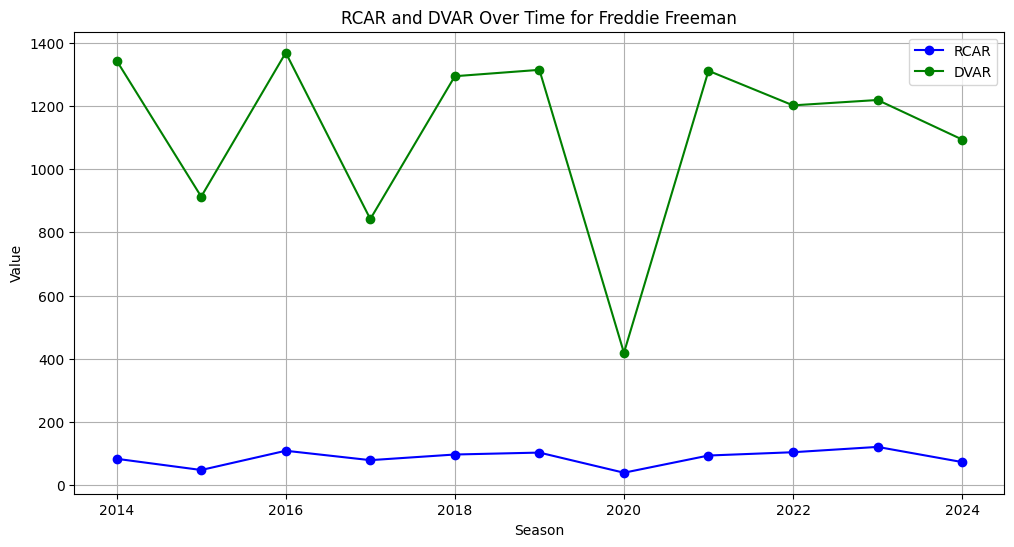

```python
def plot_player_metrics_over_time(dataframe, player_name):
    """
    Plots RCAR and DVAR over time for a specific player.

    Parameters:
        dataframe (pd.DataFrame): The dataset containing player data.
        player_name (str): The name of the player to analyze.

    Returns:
        None
    """
    # Filter data for the specified player
    player_data = dataframe[dataframe['Name'] == player_name]

    # Check if player data exists
    if player_data.empty:
        print(f"No data found for player: {player_name}")
        return

    # Sort by season to ensure chronological order
    player_data = player_data.sort_values(by='Season')

    # Plot RCAR over time
    plt.figure(figsize=(12, 6))
    plt.plot(player_data['Season'], player_data['RCAR'], marker='o', label='RCAR', color='blue')
    plt.plot(player_data['Season'], player_data['DVAR'], marker='o', label='DVAR', color='green')
    plt.title(f"RCAR and DVAR Over Time for {player_name}")
    plt.xlabel("Season")
    plt.ylabel("Value")
    plt.legend()
    plt.grid(True)
    plt.show()

# Example usage for a specific player
plot_player_metrics_over_time(merged_df, "Freddie Freeman")
```

#### Freddie Freeman

- **RCAR:** Remains relatively stable across seasons, indicating consistent offensive value over time.
- **DVAR:** Shows significant variability, with notable peaks and troughs. The sharp decline in 2020 aligns with the shortened season, impacting defensive opportunities.

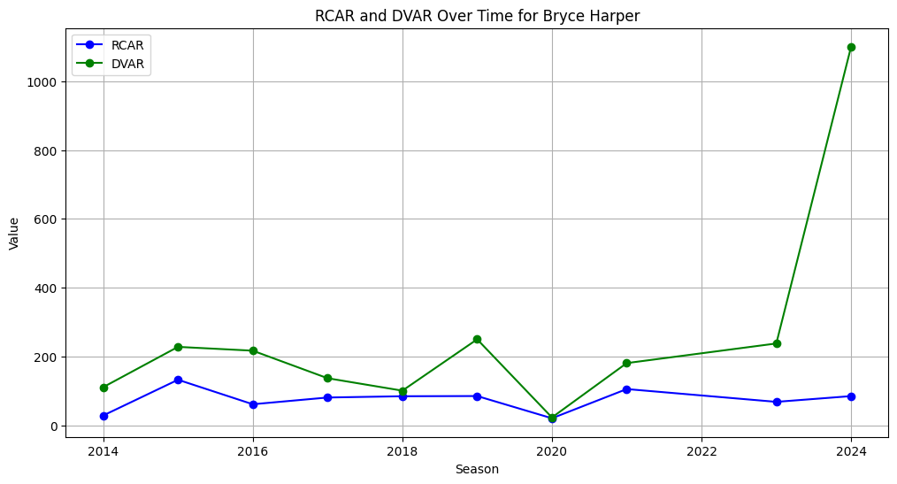

```python
plot_player_metrics_over_time(merged_df, "Bryce Harper")
```

#### Bryce Harper

- **RCAR:** Displays a steady performance trend with some fluctuations. Harper's offensive value spiked in the early years but remains stable in recent seasons.
- **DVAR:** Notable peak in 2024, but Harper also moved to First Base (1B) in the 2024 season. He had previously played Outfield.

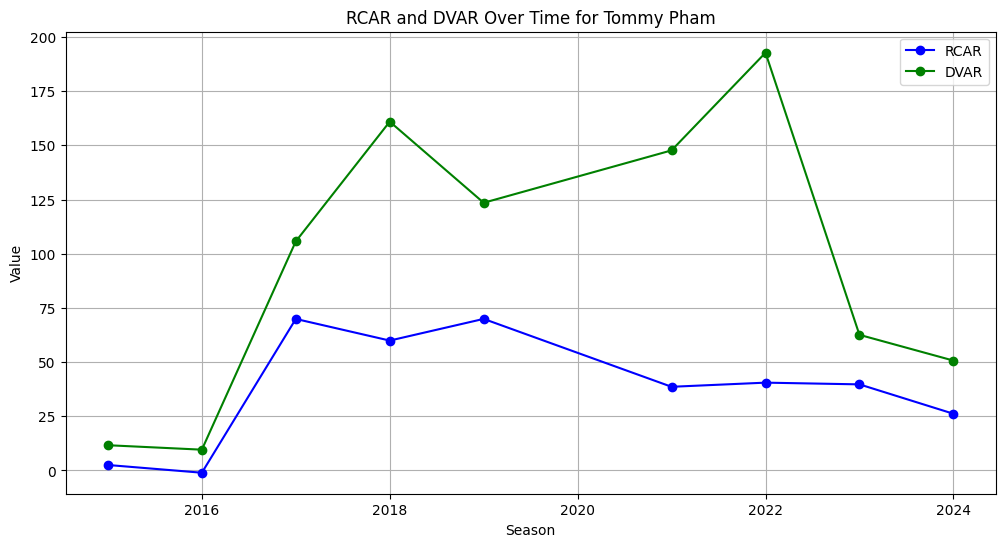

```python
plot_player_metrics_over_time(merged_df, 'Tommy Pham')
```

#### Tommy Pham

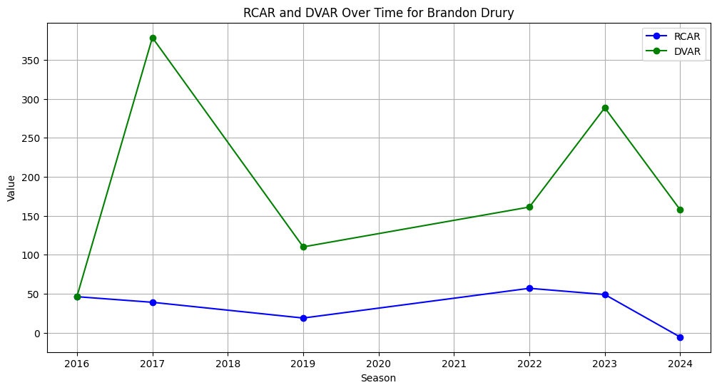

```python
plot_player_metrics_over_time(merged_df, "Brandon Drury")
```

#### Brandon Drury

- **RCAR:** Maintains a relatively stable yet low offensive contribution, peaking slightly in later seasons.
- **DVAR:** Highly volatile with a massive peak in 2017, followed by a sharp drop. The value stabilizes later but at a lower level, showing inconsistency in defensive contributions.

### Conclusion

These player-specific RCAR and DVAR trends highlight the importance of analyzing both offensive and defensive metrics to understand a player's overall contribution. The variability across seasons can be attributed to external factors such as team changes, injuries, or changes in roles. These visualizations offer a comprehensive way to evaluate player performance trajectories.

While Freeman and Harper are everyday stars, Pham and Drury often serve in platoon-style roles. These players may play different positions and be used on a situational-basis. They are analyzed here to give a comparison of an everyday player to someone who could serve a 'replacement' role on many teams.

## Conclusions and Recommendations

### Hypothesis Evaluation:

1. **RCAR Hypothesis:**
   - **Null Hypothesis (H₀):** RCAR does not effectively measure a player's offensive value relative to a replacement-level player.
   - **Alternative Hypothesis (H₁):** RCAR effectively measures a player's offensive value relative to a replacement-level player.
   - **Conclusion:** Based on the results of the ANOVA (F = 33.14, p = 0.00) and its strong correlation with WAR (r = 0.81, p = 0.00), we reject the null hypothesis for RCAR and accept the alternative hypothesis. RCAR effectively measures offensive contributions relative to replacement-level players and aligns well with established benchmarks.
2. **DVAR Hypothesis:**
   - **Null Hypothesis (H₀):** DVAR does not effectively measure a player's defensive value relative to a replacement-level player.
   - **Alternative Hypothesis (H₁):** DVAR effectively measures a player's defensive value relative to a replacement-level player.
   - **Conclusion:** The findings suggest accepting the null hypothesis for DVAR. While the ANOVA results (F = 460.17, p = 0.00) indicate significant differences in DVAR by position, supporting its ability to distinguish positional contributions, but the metric's weak correlation with DRS (r = 0.13, p > 0.05) highlights limitations in its alignment with established defensive benchmarks. Additionally, structural biases, such as overvaluing catchers and first basemen, further suggest that DVAR may require refinement to accurately and equitably evaluate defensive performance.

### Practical Implications:

1. **For Coaches and Analysts:**
   - RCAR offers a robust framework for assessing offensive contributions, enabling fair comparisons within and across positions.
   - DVAR provides useful insights into defensive contributions but should be interpreted cautiously, particularly for catchers and first basemen, where its values may overestimate impact.
   - The metrics' simplicity makes them accessible for amateur and collegiate teams, allowing for data-driven player evaluation even with limited resources.
2. **For Players:**
   - RCAR percentile rankings highlight areas for improvement in offensive performance, while DVAR rankings provide feedback on defensive contributions. Players in positions like catcher and first base should note that DVAR may reflect role-specific metrics rather than pure defensive skill.

### Limitations and Future Work:

1. **DVAR Correlation and Overvaluation:**
   - The weak correlation between DVAR and DRS and its overvaluation of catchers and first basemen indicate a need for further refinement. Adjusting DVAR to account for positional context, such as reducing the weight of putouts for first basemen, could enhance its accuracy.
2. **Sample Size and Level of Play:**
   - While RCAR and DVAR are validated with MLB data, additional testing on amateur or collegiate datasets would ensure these metrics generalize effectively across different levels of play.

### Recommendations:

1. **Adoption by Amateur Teams:**
   - Coaches and analysts should incorporate RCAR and DVAR into evaluations, leveraging their accessibility and positional specificity to make equitable and data-driven decisions.
   - Training resources and tutorials should be developed to assist teams in computing these metrics using freely available tools like Python or Excel.
2. **Refinements to Metrics:**
   - Future iterations of DVAR should address positional overvaluation by incorporating advanced defensive data and re-evaluating the weight of putouts for certain positions.
   - Incorporating additional defensive metrics, such as framing or range data, could improve DVAR’s reliability and alignment with professional benchmarks like DRS.